# Introduction to R Programming

University of Manchester

2020

# Contact Details

David Jenkins | david.jenkins-5@manchester.ac.uk

# Introduction

This document is to provide an introduction to using the statistical computing language known as R. This includes how to read data into R, perform various calculations, obtain summary statistics on data and carry out simple analyses. R’s usage is varied: it has been used extensively in academia, but not as often in the healthcare sector (in particular the NHS) and industry. However, this is slowly changing. This introduction will not introduce you to an extensive list of commands, nor will it make you an expert R-programmer. What it will do is show some of the most used commands and functions that are used in the field, and best practices for writing your own scripts.

After the first workshop, students should

1. Know key constructs in the R programming language that read, manipulate and analyse data
2. Be able to design/develop simple, but complete, scripts to analyse data
3. Be able to transfer knowledge and practical skills between datasets/tasks

# What is R?

R is a free, open-source statistical computing language and environment which was originally created by Ross Ihaka and Robert Gentleman at the University of Auckland, New Zealand, and is now developed by the R Development Core Team. The first version of the software was released in 1997. It is an implementation of the S language that was originally developed by J. M. Chambers at AT&T’s Bell Laboratories in the late 1980’s. There is a commercial version of S called S-PLUS which is sold by TIBCO Software Inc. S-PLUS is rather expensive but works in a very similar way to the freely available R, so why not use R?

## R’s main features

R is so popular around the world because it:

- is a powerful system for calculation, graphical and statistical analysis
- is free, open source, available on all operating systems
- has a large and growing community worldwide
- allows reproducibility of graphics & statistics
- allows simulation and modelling of data
- is flexible to be extended to almost any use case

There are also other well-documented positives to using R (e.g., blog post http://monkeysuncle.stanford.edu/?p=367).

Alternative statistical software are Stata, SAS, SPSS, Minitab or StatsDirect, however, for the reasons cited above, R is our favourite!

## Resources to learn more about R

In general, support for any problem you might have when using R to analyse some data can be found on Google (i.e. typing “R how to…”). Below, some more specific suggestions to learn more about R.

### Suggested textbooks

There are a number of textbooks available which discuss using R for statistical data analysis. Exemples are:

- Crawley, M. J. (2014), Statistics: An Introduction using R. (Wiley);
- Matloff, N. (2009), The Art of R Programming (No starch press);
- Wickham & Grolemund (2016), R for Data Science (O’Reilly, available for free at http://r4ds.had.co.nz/index.html)

### Reference cards and cheatsheets

- General R Basics  
  https://cran.r-project.org/doc/contrib/Short-refcard.pdf  
  https://www.stats.ox.ac.uk/~snijders/siena/Rrefcard.pdf  
  http://www.u.arizona.edu/~kuchi/Courses/MAT167/Files/R-refcard.pdf https://www.rstudio.com/resources/cheatsheets/
- RStudio Guide http://www.rstudio.com/wp-content/uploads/2016/01/rstudio-IDE-cheatsheet.pdf

# R and RStudio

We use RStudio integrated development environment (IDE) to demonstrate how to use R. An IDE is a software application that provides comprehensive facilities to computer programmers for software development. Think about it as an instrument that allows you to use R more easily. RStudio includes docked windows for your console and syntax-highlighting editor that supports direct code execution, as well as tools for plotting, history, debugging and workspace management. Only a subset of these are available in the original R editor.

## Downloading and installing R and Rstudio

You can download and install a copy of the latest version of R for free on your own computer from:

http://www.stats.bris.ac.uk/R/

Similarly, to install RStudio, click on the link

https://www.rstudio.com/products/rstudio/download/

You can either run the programs, or save them to your computer and run them from there. When installing, you can accept the default settings.

*Note:* As we have already said, RStudio is only a tool that allows us to use R. Therefore, you need to have it installed on your computer to be able to use it.

#Introduction to R

[figure not shown]

Screenshot of Studio upon opening

[figure not shown]

Working screenshot of R Studio

Console area

- Command line
- Execute quick commands
- Displays executed code
- Displays results of executed code

Code area

- Where we keep records of our work
- Write sripts/code
- Scripts can be saved

Workspace area

- Shows what is loaded in memory, eg data.
- Stores any object, value, function or data you create during your R session (we will cover what these are later)
- The history tab keeps a record of all previously submitted commands

Plot, help and package area

- The plots tab displays any graphs/figures created during the R session
- The package tab shows a list of all add-ons currently available in RStudio (but more can be installed)
- The help tab provides information about R and command. It can be very helpful but it is not always the case (we will discuss this later)

# At the beginning of each R session

To begin your session, first

1. Go to  
   Session > Set Working Directory > Choose Directory  
   and create a folder where you will work from today (i.e. no need to recreate it in next workshops). This folder should include any datasets you wish to use.

You can check your current working directory by using the command getwd()

2. Type into your console the below to remove any previously saved data.

```r
rm(list=ls())
```

# Creating your first script

File > New File > R Script (or *Ctrl + Alt + N*)

Create a script and paste the following. We will explain the intricacies of the commands later.

```r
###############################################################
## Introducing to R
## 01 October 2018
##

rm(list=ls())  # Clean our R environment
x <- c(5, 1, 7, 9, 3, 6, 10, 14, 12, 8)  # insert the row of data manually
ls()  # list all variables saved in our R environment
max(x)
min(x)
range(x)
```

Now you can save your script, the extension of the file will be .r or .R to recognise that this is an R script and should be opened in R only. To ‘Run’ the instructions (i.e. send them to the console and get our results), we can use the ‘Run’ button that is located at the top right corner of the script. Alternatively, press Ctrl+ENTER on windows (cmd+ENTER on a mac).

Give it a try running the above code!

[figure not shown]

Screenshot of Studio during use

Your code will be run/exectuted in the Console (bottom left window).  
We will continue to work with our R script for the remainder of the session (and course) to allow you to refer back at a later date. Please annotate and comment your code throughout all sessions using the $\#$ symbol as above.

## Notes & Tips

- R is case sensitive.
- Commands are separated either by a semicolon (;) or by a newline.
- The $\#$ character can be used to make comments. R doesn’t execute the rest of the line after the $\#$ symbol - it ignores it.
- Previous session commands can be accessed via the up and down arrow keys on the keyboard. This can save time typing as these can be edited and reused.
- Any output shown in this document has $\#\#$ at the beginning of the line to distinguish that it is output rather than input.
- There are many functions already built in to R. There are also functions which are hosted in packages which are required to be installed and loaded within the session.

# Working with data

We are approaching the learning from the perspective of a data analyst. Therefore, we are going to jump in by looking at some real data. We will use two clinical datasets:

- One from a case-control study on coronary heart disease (CHD). The Coronary Risk-Factor Study was carried out in three rural areas in South Africa, in the White Cape region, where incidence of heart disease is particularly high. This contains different type of information for each patient, ranging from age to family history of CHD.
- One from admissions data for an A&E department over 24 hours (A and E). It contains data for 230 patients, with all relavant information for each patient (e.g. time of arrival, minutes on A&E, minutes from arrival to seen)

We will explore them shortly; first we need to load the data into R.

## Loading data

Reading data into R is straightforward.  
First make sure your data files are saved in the same place your R session is working from. This can be found with the function $\verb|getwd()|$.

```r
getwd()               # get the name of your current working directory
```

If this is not the directory you want to work in, use the command $\verb|setwd()|$ with the path to the directory you wish to work in, or click on Session > Set Working Directory > Choose Directory… and then find the directory in the file explorer window.

The command to import the data file from this location depends on the type of file you are importing.

Typically we load .csv (Comma separated values) files

```r
CHD <- read.csv2("CHD.csv", sep=",") # or we can load a csv (Comma separated values) files
AandE <- read.csv("A and E Data.csv", header=T)
```

but R also allows many other types, such as excel files. For this, we can use the function read.xlsx from the xlsx package. It reads from an Excel spreadsheet and returns a data frame. The following shows how to load an Excel spreadsheet named “CHD.xlsx” and save it as a dataframe called CHD also.

```r
install.packages("xlsx")  # First install the xlsx R package
library(xlsx)                   # load the xlsx package
CHD <- read.xlsx("CHD.xlsx",  sheetIndex = 1)  # read in the data from sheet number 1
```

## How do I format my data?

Datasets are usually stored as an object called a data frame. This is a special class of object in R. We can explicitly define a data frame using the command $\verb|data.frame|$. A data frame is the most widely used class of object to store data in the R community, as it allows to store vectors of different data classes (i.e. integer, decimal, characters, factors and dates) in the same object. This allows us to obtain a data formatting similar to the below.

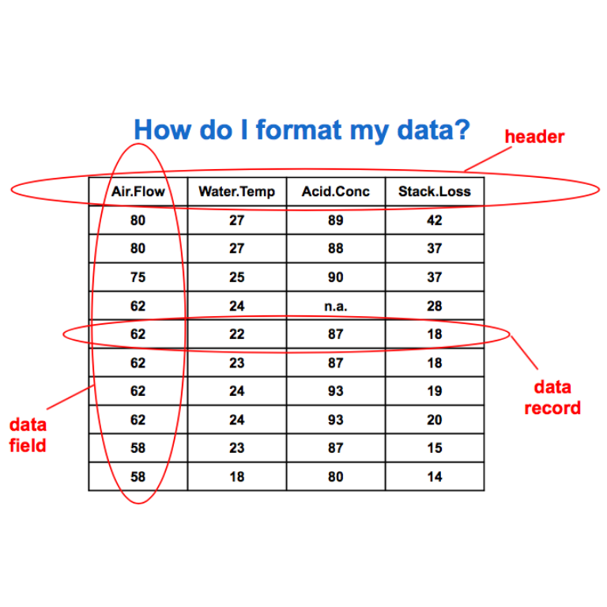

Format of data.

In particular, the main principles to consider when formatting data are:

- All variables (or data fields) should have a separate column (don’t mix meaning in a column, add a new column if necessary)
- All data from the same variable go in the same column
- Each row should correspond to only one observation (or data record) in the data (e.g. a patient, a car)
- Label your columns with terms that are meaningful to other people
- Do not leave white spaces in your variable names (use underscore or period, e.g. Air.Flow or air_flow) or data cells (use ‘n.a.’)
- Make sure headers are the first row in file
- Don’t leave any blank row or columns in a file
- Don’t color code cells (add a new column with an indicator variable, e.g. ‘gfp_tagged’ with values ‘y/n’)
- Save your data as plain text files in tab delimited or comma separated value (CSV) format.

## Data quality

Data quality is an issue for any organisation. In particular, it is has been recognised as an issue in the NHS and NHS organisations are implementing strategies to audit and improve the quality of data produced. The key terms related to data quality are defined below in the context of patient care. However, most of these principles are directly transferable to other contexts.

| Characteristic Meaning | Characteristics of data quality and their meanings |
| --- | --- |
| Accurate | Data are correctly input and reflect exactly patient characteristics |
| Available or accessible | Data enable identifying specific patients or events correctly and can be retrieved relatively rapidly when needed. |
| Complete | All the elements of information needed are present in the designated data source and no elements of needed information are missing. |
| Fit for purpose | Data are suitable for their intended purpose. |
| Relevant | Data are of interest to data users to enable them to meet the intended purpose of the data. |
| Reliable | Data are the same no matter who collects the data or when a person collects the data. |
| Timely | Original data are recorded contemporaneously with the provision of patient care or service and are available in time to make safe decisions about the quality of patient care or service. |
| Valid | Data meaningfully represent exactly what they are intended to represent. |

Patient care data must be also secure and confidential.

## Discrete and continuous data

**Discrete data** are data that have finite (usually whole integer) value. Using our CHD data set, “chd” is an example of discrete data. Another classic example is the number of students in a class. We can say that there are 39 or 40 students in a class, but it does not make sense to say that there are 39.5.

The “Mins.on.AE” records the time spent by a patient in the A&E department is an example of **continuous data**. This data is called continuous because the scale of measurement - time - has meaning at all points between the numbers given, e.g. we can measure time spent on A&E as 35 mins and 240 mins and even 129.5 mins.

## Exploring data

If you know your dataset is large then viewing your data will not be helpful and will slow your computer down.

However, as a check that your data is imported correctly you can use the following commands.

Let’s check the CHD dataset.

```r
dim(CHD)  # What is the dimension of CHD?
```

```
## [1] 462  10
```

```r
str(CHD)  # What is the structure of my data? In the format: Names/Variable type/Example of the first few values, ....
```

```
## 'data.frame':    462 obs. of  10 variables:
##  $ sbp      : int  160 144 118 170 134 132 142 114 114 132 ...
##  $ tobacco  : Factor w/ 214 levels "0","0.01","0.02",..: 81 2 9 196 90 183 146 147 1 1 ...
##  $ ldl      : Factor w/ 329 levels "0.98","1.07",..: 239 165 100 269 101 270 96 172 126 242 ...
##  $ adiposity: Factor w/ 408 levels "10.05","10.29",..: 146 247 311 386 232 369 53 39 87 291 ...
##  $ famhist  : Factor w/ 2 levels "Absent","Present": 2 1 2 2 2 2 1 2 2 2 ...
##  $ typea    : int  49 55 52 51 60 62 59 62 49 69 ...
##  $ obesity  : Factor w/ 400 levels "14.7","17.75",..: 177 306 313 367 202 351 38 100 162 335 ...
##  $ alcohol  : Factor w/ 249 levels "0","0.19","0.26",..: 249 78 137 104 196 46 84 209 81 1 ...
##  $ age      : int  52 63 46 58 49 45 38 58 29 53 ...
##  $ chd      : int  1 1 0 1 1 0 0 1 0 1 ...
```

```r
colnames(CHD)  # What are the names of my columns?
```

```
##  [1] "sbp"       "tobacco"   "ldl"       "adiposity" "famhist"   "typea"
##  [7] "obesity"   "alcohol"   "age"       "chd"
```

Let’s check the AandE dataset.

```r
dim(AandE)  # What is the dimension of A&E?
```

```
## [1] 230  21
```

```r
str(AandE)  # What is the structure of my data? In the format: Names/Variable type/Example of the first few values, ....
```

```
## 'data.frame':    230 obs. of  21 variables:
##  $ Arrival.Month            : Factor w/ 1 level "Jun-12": 1 1 1 1 1 1 1 1 1 1 ...
##  $ day_type                 : Factor w/ 1 level "Weekday": 1 1 1 1 1 1 1 1 1 1 ...
##  $ Arrival.Day              : Factor w/ 1 level "Fri": 1 1 1 1 1 1 1 1 1 1 ...
##  $ Arrival.Hour             : int  0 0 0 0 1 1 1 1 1 1 ...
##  $ Arrival_Date_Time        : Factor w/ 218 levels "01/06/12 00:35",..: 1 2 3 4 5 6 7 8 9 10 ...
##  $ Departure_Date_Time      : Factor w/ 207 levels "  ","01/06/12 01:56",..: 5 3 6 8 9 10 2 11 4 7 ...
##  $ Mins.on.AE               : int  234 129 237 238 239 240 35 238 114 171 ...
##  $ arrival_date_dt          : Factor w/ 1 level "01-Jun-12": 1 1 1 1 1 1 1 1 1 1 ...
##  $ Over.4.hrs               : int  0 0 0 0 0 0 0 0 0 0 ...
##  $ X4.to.12.hrs             : int  0 0 0 0 0 0 0 0 0 0 ...
##  $ Triage_Category          : Factor w/ 4 levels "Patients whose conditions are not true accidents o",..: 2 2 4 2 4 3 2 3 4 2 ...
##  $ Triage_Main_Code         : int  3 3 4 3 4 2 3 2 4 3 ...
##  $ Triage_Colour            : Factor w/ 4 levels "BLUE","GREEN",..: 4 4 2 4 2 3 4 3 2 4 ...
##  $ Source_Of_Ref            : Factor w/ 12 levels "Carer","Emergency Services",..: 2 11 11 11 11 11 11 2 11 11 ...
##  $ Arrival_Mode             : Factor w/ 5 levels "Ambulance","Police",..: 1 1 3 1 1 3 3 1 3 1 ...
##  $ Attendance_Disposal      : Factor w/ 15 levels "A&E Review Clinic",..: 2 8 1 2 2 6 2 2 8 11 ...
##  $ presenting_complaint     : Factor w/ 78 levels "","Abcess","Abdo pain",..: 47 15 77 75 66 15 3 67 46 41 ...
##  $ Attendance_Category      : Factor w/ 2 levels "First Accident And Emergency Attendance",..: 1 1 1 1 1 1 1 1 1 1 ...
##  $ Arrival_To_Seen          : int  164 129 175 117 161 208 35 0 114 146 ...
##  $ Time_To_Initial_Asessment: int  1 0 77 0 0 2 12 0 7 0 ...
##  $ Arrival_Mode_Code        : int  1 1 2 1 1 2 2 1 2 1 ...
```

```r
colnames(AandE)  # What are the names of my columns?
```

```
##  [1] "Arrival.Month"             "day_type"
##  [3] "Arrival.Day"               "Arrival.Hour"
##  [5] "Arrival_Date_Time"         "Departure_Date_Time"
##  [7] "Mins.on.AE"                "arrival_date_dt"
##  [9] "Over.4.hrs"                "X4.to.12.hrs"
## [11] "Triage_Category"           "Triage_Main_Code"
## [13] "Triage_Colour"             "Source_Of_Ref"
## [15] "Arrival_Mode"              "Attendance_Disposal"
## [17] "presenting_complaint"      "Attendance_Category"
## [19] "Arrival_To_Seen"           "Time_To_Initial_Asessment"
## [21] "Arrival_Mode_Code"
```

After this we might want to view the data. This can be done using the function $\verb|head()|$ or $\verb|tail()|$ which displays the top or bottom rows of the dataset, respectively. The default is to display the top/bottom 6 rows but we can choose how many rows of the data we wish to view, e.g.,

```r
head(CHD)
```

```
##   sbp tobacco  ldl adiposity famhist typea obesity alcohol age chd
## 1 160      12 5.73     23.11 Present    49    25.3    97.2  52   1
## 2 144    0.01 4.41     28.61  Absent    55   28.87    2.06  63   1
## 3 118    0.08 3.48     32.28 Present    52   29.14    3.81  46   0
## 4 170     7.5 6.41     38.03 Present    51   31.99   24.26  58   1
## 5 134    13.6  3.5     27.78 Present    60   25.99   57.34  49   1
## 6 132     6.2 6.47     36.21 Present    62   30.77   14.14  45   0
```

```r
tail(CHD, 3)
```

```
##     sbp tobacco   ldl adiposity famhist typea obesity alcohol age chd
## 460 108       3  1.59     15.23  Absent    40   20.09   26.64  55   0
## 461 118     5.4 11.61     30.79  Absent    64   27.35   23.97  40   0
## 462 132       0  4.82     33.41 Present    62    14.7       0  46   1
```

If your data is relatively small (less than 20 columns and 50 rows) then it may be sensible to view your dataset. You can do this using

```r
View(CHD)
```

where a new window will open displaying your dataset or you can view the data directly in the console simply type the name of your dataset, i.e., $\verb|CHD|$.

Key Tip: The $ sign extracts the variable you are interested in:

```r
head(CHD$obesity)
```

```
## [1] 25.3  28.87 29.14 31.99 25.99 30.77
## 400 Levels: 14.7 17.75 17.81 17.89 18.36 18.46 18.5 18.75 19.15 19.3 ... 46.58
```

You may have noticed that ‘obesity’ has been imported as a factor variable in R with 400 levels. This means that R has stored obesity as a discrete variable with 400 groups. This is clearly incorrect and needs to be reclassified. Having variables defined with an incorrect class can cause problems and lead to errors in your analysis. Checking if your data is labeled as the correct class is VERY important.

To check the type of variable, you can use $\verb|str( )|$ to list all types of variables in a dataset as above, or you can directly use $\verb|class( )|$,

```r
class(CHD$obesity);
```

```
## [1] "factor"
```

```r
class(CHD$famhist);
```

```
## [1] "factor"
```

If you wish to check if the data is of a certain type of variable then you can use

```r
is.numeric();
is.character();
is.factor();
```

or to change the type of variable

```r
as.numeric();
as.character();
as.factor();
```

## Converting a factor to numeric

To change the obesity variable to be continuous data we need to write as.numeric(as.character()) and overwrite the original variable using

```r
CHD$obesity <- as.numeric(as.character(CHD$obesity))
is.numeric(CHD$obesity)
```

```
## [1] TRUE
```

```r
class(CHD$obesity)
```

```
## [1] "numeric"
```

We need to use the combination of functions because we are changing from a factor to a numeric variable. If we try to change from a factor to a numeric without changing to a character first, we will not get the same answer. This is because for variables that are factors, each unique entry is assigned a number and when we try to convert the factor variable directly to numeric, we obtain these assigned numbers rather than the values. For example, if we look at the variable tobacco, which we would also like as numeric, then we can see that the first 10 entries are

```r
CHD$tobacco[1:10]
```

```
##  [1] 12   0.01 0.08 7.5  13.6 6.2  4.05 4.08 0    0
## 214 Levels: 0 0.01 0.02 0.03 0.04 0.05 0.06 0.07 0.08 0.09 0.1 0.12 ... 9.9
```

and we can see that outputting these entries, we also get a line beginning ‘214 Levels: 0 0.01’. This means that there are 214 unique entries in the variable tobacco. All the values of 0 are level 1, all the values of 0.01 are level 2, etc. Now, if we try and change the tobacco variable to numeric using as.numeric(), we get the first 10 entries to be

```r
as.numeric(CHD$tobacco)[1:10]
```

```
##  [1]  81   2   9 196  90 183 146 147   1   1
```

which does not look like the numbers we expected. This is because the as.numeric() function returns the levels of the values as opposed to the numbers that we see if we look at the variable. This is clearer to see if we check that the levels do match up to the values we saw:

```r
levels(CHD$tobacco)[81]
```

```
## [1] "12"
```

```r
levels(CHD$tobacco)[2]
```

```
## [1] "0.01"
```

```r
levels(CHD$tobacco)[9]
```

```
## [1] "0.08"
```

```r
head(CHD$tobacco)[1:3]
```

```
## [1] 12   0.01 0.08
## 214 Levels: 0 0.01 0.02 0.03 0.04 0.05 0.06 0.07 0.08 0.09 0.1 0.12 ... 9.9
```

In order to avoid this issue, we need to change to a character first. To see what this does, let’s look at the first 10 entries again.

```r
as.character(CHD$tobacco)[1:10]
```

```
##  [1] "12"   "0.01" "0.08" "7.5"  "13.6" "6.2"  "4.05" "4.08" "0"    "0"
```

We see that the values are now surrounded by quote marks and we no longer have the list of levels appearing. R is now handling each of the vector entries as text so we can now convert to a number:

```r
as.numeric(as.character(CHD$tobacco))[1:10]
```

```
##  [1] 12.00  0.01  0.08  7.50 13.60  6.20  4.05  4.08  0.00  0.00
```

Remember, we need to save over the vector with the converted vector to be able to treat it as a number, so we need the following code.

```r
CHD$tobacco  <- as.numeric(as.character(CHD$tobacco))
```

## The joys of cleaning data (Manipulating data)

Real life data is messy; statisticians and data scientists spend a large proportion of their time cleaning data. There is no ‘one size fits all’, when it comes to data cleaning. Data scientists, need to be sceptical about the data that they have. For instance, negative time and age can ring a bell. Similarly, missing values can cause issues in that we need to establish the reason that they may be missing, even for observed data the true values may differ, for example self-reported weights are known to be downward biased. These are only a few simple examples of what we need to deal with.

```r
# Change class of variables to numeric
CHD$obesity  <- as.numeric(as.character(CHD$obesity))
CHD$tobacco  <- as.numeric(as.character(CHD$tobacco))
CHD$ldl      <- as.numeric(as.character(CHD$ldl))
CHD$adiposity <- as.numeric(as.character(CHD$adiposity))
CHD$alcohol  <- as.numeric(as.character(CHD$alcohol))
```

## Handling objects

Before we go straight into working with the data, we first need to discuss vectors and matrices

### Vectors

A *vector* is a sequence of data elements (or components) of the same basic type. We can consider it as simply as a row of data. We can create a vector by using the $\verb|c()|$ function. Here is a vector containing three numeric values 8, 1 and 3.

```r
b <- c(8, 1, 3)  # to input a vector we use the syntax c( ) with commas
b*3  # R performs componentwise multiplication
```

```
## [1] 24  3  9
```

In the last command, 3 is known as a scalar. A scalar is usually said to be a physical quantity that only has magnitude and no other characteristics.

To extract an element from a a vector, we use the square brackets and the index of the data element we are interested in. For example, to extract the second component of a vector we use:

```r
b[2]
```

```
## [1] 1
```

*Note:* In R, conversely to other programming languages, the indices within vectors (and all other data structures) starts from 1 (and not from 0).

We can use $\verb|c|$ also within square brackets to combine indices together and access different data elements at the same time. For example, it can be used to access two elements of $\verb|b|$, e.g., the second and third

```r
b[c(2,3)]
```

```
## [1] 1 3
```

### Matrices

A matrix is a collection of data elements arranged in a two-dimensional rectangular layout. We can create matrices in two ways. First, we can use $\verb|matrix|$ on a single vector, specifying the number of columns or rows to split the data into.

```r
matrix(c(1:10), nrow = 2)
```

```
##      [,1] [,2] [,3] [,4] [,5]
## [1,]    1    3    5    7    9
## [2,]    2    4    6    8   10
```

```r
matrix(c(1:10), ncol = 2)
```

```
##      [,1] [,2]
## [1,]    1    6
## [2,]    2    7
## [3,]    3    8
## [4,]    4    9
## [5,]    5   10
```

Alternatively, we can combine multiple vectors together with $\verb|rbind|$ or $\verb|cbind|$. For example:

```r
d <- c(1, 2, 5)
cbind(b, d)
```

```
##      b d
## [1,] 8 1
## [2,] 1 2
## [3,] 3 5
```

```r
rbind(b, d)
```

```
##   [,1] [,2] [,3]
## b    8    1    3
## d    1    2    5
```

> **Exercise 1:**

**a) What is the difference between cbind() and rbind()? Are there cases when it is not possible to use them? Hint - try creating a variety of vectors and/or matrices and binding them**

**b) What happens when we multiply 2 vectors together rather than multiplying by a scalar? Can you think of an example when multiplying a vector by a scalar (or vector) would be useful?**

### Which objects are stored in my R environment?

You can ask R to print a *list* of the objects that are currently saved in your environment, simply by typing

```r
ls()
```

```
## [1] "AandE" "b"     "CHD"   "d"     "img"
```

These can also be seen in RStudio by clicking on the Environment tab where the same objects are shown.

To *remove* an object from the environment, for example $\verb|b|$, we can type

```r
rm(b)
```

To clear the R environment and remove all objects and previously saved data, use

```r
rm(list = ls())
```

Here, you are calling the function $\verb|rm()|$, which takes a list of names as input and removes the objects with the related names. We create the list with the above mentioned $\verb|ls()|$.

### Extracting data

Similar to (x,y) coordinates, the matrix indices always read [ROWS, COLUMNS]. To extract a single cell value from the second row and third column, we type

```r
CHD[2, 3]
```

```
## [1] 4.41
```

Omitting column values implies *all* columns; here all columns in row 2

```r
CHD[2, ]
```

```
##   sbp tobacco  ldl adiposity famhist typea obesity alcohol age chd
## 2 144    0.01 4.41     28.61  Absent    55   28.87    2.06  63   1
```

We can also use ranges - rows 2 and 3, columns 2 and 3

```r
CHD[2:3, 2:3]
```

```
##   tobacco  ldl
## 2    0.01 4.41
## 3    0.08 3.48
```

We can also access variables directly by using their names, either with the object[ ,“variable”] notation or object$variable notation.

To extract a variable from your data set such as $\verb|tobacco|$, you require the $ sign, e.g., $\verb|CHD|$$$\verb|tobacco|$ extracts the variable tobacco from the $\verb|CHD|$ dataset.

To get the first 10 rows of variable $\verb|tobacco|$ we can use three methods

```r
CHD[1:10, "tobacco"]
```

```
##  [1] 12.00  0.01  0.08  7.50 13.60  6.20  4.05  4.08  0.00  0.00
```

```r
CHD$tobacco[1:10]
```

```
##  [1] 12.00  0.01  0.08  7.50 13.60  6.20  4.05  4.08  0.00  0.00
```

```r
head(CHD$tobacco,10)
```

```
##  [1] 12.00  0.01  0.08  7.50 13.60  6.20  4.05  4.08  0.00  0.00
```

The $\verb|c|$ function is widely used to combine values of common type together to form a vector. For example, it can be used to access non-sequential rows and columns from a data frame.

```r
CHD[c(1,3,5), 1]  # get column 1 for rows 1, 3 and 5
```

```
## [1] 160 118 134
```

and we can get row 1 and row 6 values for variables age, sbp and chd status

```r
CHD[c(1,6), c("age", "sbp", "chd")]
```

```
##   age sbp chd
## 1  52 160   1
## 6  45 132   0
```

If there were no variable names, or we wanted to change the names, we could use $\verb|colnames|$

```r
colnames(CHD)
```

```
##  [1] "sbp"       "tobacco"   "ldl"       "adiposity" "famhist"   "typea"
##  [7] "obesity"   "alcohol"   "age"       "chd"
```

To change one variable name, just use indexing

```r
colnames(CHD)[7] <- "BMI"
```

> **Exercise 2:**

**a) Calculate the difference between BMI and adiposity in the CHD data set and bind these new values to the data. Are the values in this new vector what you expected? Explain why.**

**b) Alcohol is in weekly units but we want to assess the daily alcohol intake of each individual. Add a new column with this information.**

**c) In the A and E data do you notice anything unusual about the data for patient 22.**

**d) A lot of data is already recorded in the A and E data but we might want to assess the time from first assessment to when a patient is seen in our A&E department. Add a new column to the data which is the number of hours from first assessment to when seen. Can you spot any problems in this new vector?**

# Summarising Data

We are in an era where large volumes of data are generated. Summarising large volumes of data can often help draw out patterns and results. We aim to describe and explain differences in the distribution of outcomes of interest between populations.

There are four principle methods used to summarise data:

1. Using simple frequencies - the number of times something occurs in a data set. This makes it possible to determine if the specific value we are interested in is unusual or common.
2. Measures of location
   1. Mean - also known as the average
   2. Median - the middle value in the ranked observations, used when the data is asymmetric.
   3. Mode - the value of the random variable in the sample which occurs with the highest frequency.
3. Measures of spread
   1. Range - the difference between the largest and smallest observations
   2. Interquartile Range - describes the middle half of the data, between the 25th and 75th centiles, reducing the effect of outlying observations
   3. Variance and standard deviation
4. Graphical methods
   1. Box plots - visual presentation of the quartiles of the data
   2. Histograms - graphical presentation of the shape of a data distribution, which we look at later.

## Mean, Median and Mode

| Mean | Add up all observation and divide by how many there are. |
| --- | --- |
| Median | Arrange in increasing order, pick the middle. If an even number of observations, take mean of middle two. |
| Mode | The “mode” is the value that occurs most often. |

### When to use mean or median

Sometimes, you need to decide if calculating the mean or median is most appropriate for what you would like to determine. Hospital length of stay is an example of data that are skewed. Skewed data have a distribution that is not symmetric, which means that the large values do not balance with the small values. Most people stay in a hospital for a few days. However, some patients have hospital stays for months on end. If you were to report the mean length of stay, this would be inflated by the few very large lengths of stay. Therefore, in this example, you would likely report the median length of hospital stay, which separates the higher half from the lower half. In general, however, most people report the mean unless you have a good reason for not doing so, such as when we have skewed data like in the hospital example above.

We are now going to get you to calculate these values for some of the information in our data but we want you see if you can do this without being shown the code. In practice we dont always know what the correct code might be. However, there are many useful tools that can help you!

## I need some help!

The help and support section of R is an invaluable resource that has contributed to the popularity of R. The Help is easily accessed by clicking on the Help tab of the bottom right window in RStudio under ‘Help’. If the formal description provided by the Help is somewhat difficult to understand, do not worry, as informative examples are provided at the bottom of each help page.

If you’re struggling to find help because you are unsure of the function to search for, type

```r
help.search("logarithm")
```

This will search the help files for functions that have something to do with “logarithm”.

As already said, consider using instruments like Google when you have a problem and do not know the answer, as there is a huge R community worldwide and the quality of the solutions found are usually good. In the logarithm case, you would type “R logarithm” and this should return the most relevant links to your topic.

> **Exercise 3:**

**From the A&E dataset, calculate the mean and median for the ‘Mins on AE’ dataset.**

**From the same dataset, calculate the mean and median for ‘Arrival to seen’.**

**From the CHD dataset, calculate the mean and variance for BMI.**

**Why is the mode less interesting/relevant for these variables?**

## Measures of Spread/Variability

### Range

The range tells use how far apart the smallest and largest measurements are, for a specified vector. For example, if we look at the variable ‘tobacco’ from the CHD data, the range can be calculated using

```r
max(CHD$tobacco)-min(CHD$tobacco)
```

```
## [1] 31.2
```

However, this measurement is highly susceptible to outlier measurements. Therefore, it can be better to consider the interquartile range instead.

###Interquartile range A simple measure of spread is the interquartile range. This is the distance between the 25th and 75th percentiles of the data.

If we line up data in order (smallest to largest), the 25th percentile is the value that occurs 25% of the way along the line; the 75th percentile is the value that occurs 75% of the way along the line.

You can use the IQR directly, the quantile function or the summary function and compute yourself

```r
IQR(CHD$tobacco)
```

```
## [1] 5.4475
```

```r
# OR
quantile(CHD$tobacco)
```

```
##      0%     25%     50%     75%    100%
##  0.0000  0.0525  2.0000  5.5000 31.2000
```

```r
# OR
summary(CHD$tobacco)[5] - summary(CHD$tobacco)[2]
```

```
## 3rd Qu.
##  5.4475
```

### Variance and standard deviation

Let’s try to quantify how much our data vary.

Consider the first 10 values of the obesity data in the CHD dataset. Let’s call our data $y$.

```r
y <- CHD$BMI[1:10]
y
```

```
##  [1] 25.30 28.87 29.14 31.99 25.99 30.77 20.81 23.11 24.86 30.11
```

If we plot the data simply in the order it was measured we can see the values vary:

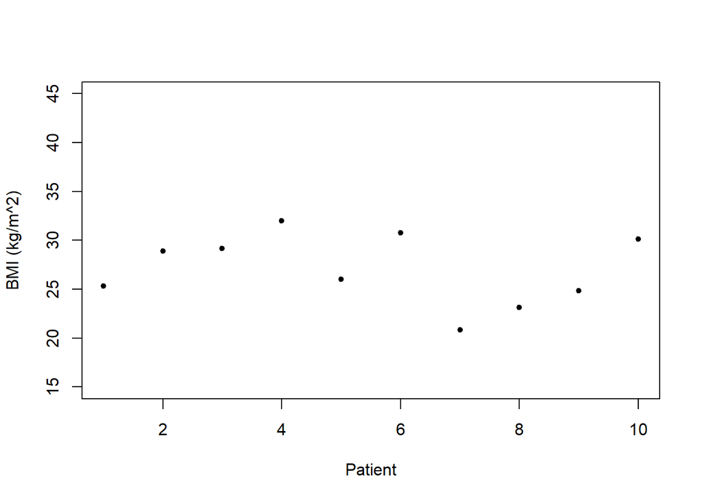

```r
plot(y, ylim=c(15,45), ylab="BMI (kg/m^2)", xlab = "Patient", pch=20)
```

We can consider looking at how much each point is away from the mean value (our red horizontal line) which we call $\bar{y}$. Recall that to compute the mean we add all our values ($y_i$) and divide by the number of values (which we call $n$), i.e.,
$$\bar{y}= \frac{1}{n} \sum_{i=1}^n y_i.$$

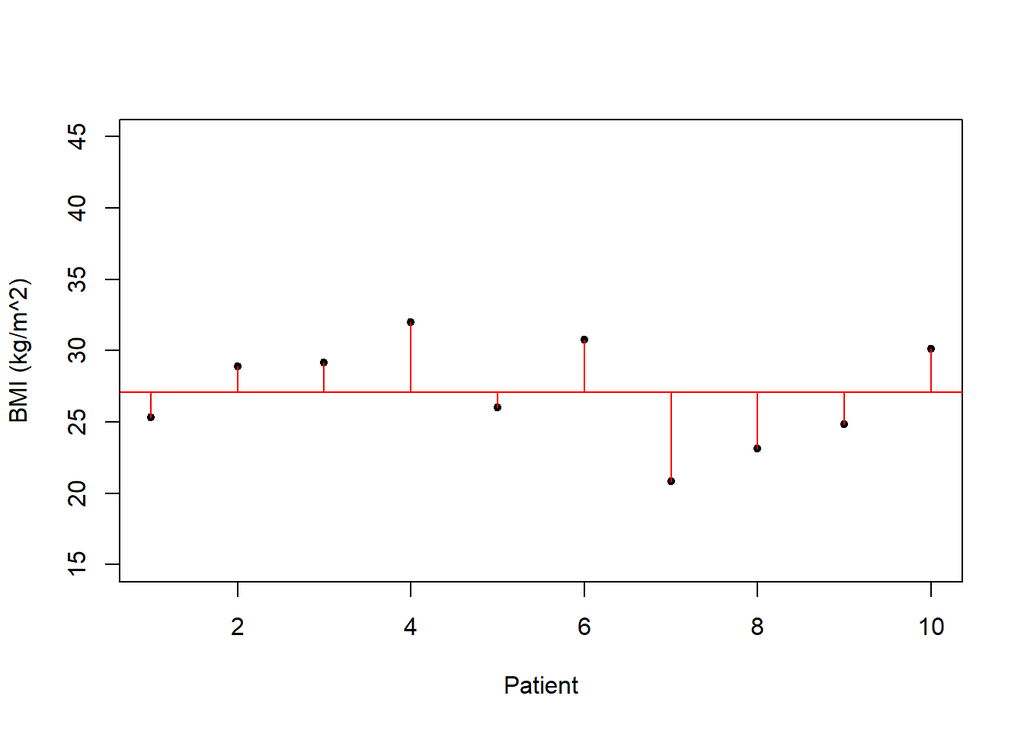

```r
plot(y, ylim=c(15,45), ylab="BMI (kg/m^2)", xlab = "Patient", pch=20)
abline(h=mean(y), col=2)  ## Add a straight line to the plot at the mean value
for(i in 1:10) lines(c(i,i), c(mean(y), y[i]), col=2) ## Add mini lines
```

However, if you wanted to measure the spread of the data and we simply added up all the vertical red lines then the negative lines will cancel out the positive lines. This is a problem. An example to demonstrate is where we have a set of 10 data points. The measurement would not distinguish between two datasets where the first had all points of the same value and the second had half the points 2 below the mean and the remaining half were 2 above the mean since the sum in both cases would be 0. However, there is an alternative! Instead, we can

1. So we can square all our lines (to make them positive) and then add them, giving a measure of how the data points vary about the mean. (Note: This will weight outliers more heavily than data very close to the mean).
2. But we want to take into account the number of data values we are adding by dividing by $(n-1)$.

The formula to compute the sample variance is

$$s^2= \frac{1}{n-1} \sum_{i=1}^n (y_i-\bar{y})^2,$$

In our example, the dataset with all 10 points taking the same value would result in $s^2$=0, whereas the dataset with half of the points 2 below the mean and half 2 above the mean would have $s^2$=4.44.

R has a built in function to easily compute the variance

```r
var(y)
```

Use the following code to find the values of 0 and 4.44 from the above example described.

```r
y1<-c(5,5,5,5,5,5,5,5,5,5)
y2<-c(3,3,3,3,3,7,7,7,7,7)
mean(y1)
mean(y2)
var(y1)
var(y2)
```

> **Note: Read Crawley Page 53 to see why do we divide by (n-1) when estimating the variance from a sample of data.**

A slightly more complex, but important, measure of variability is the standard deviation which is the square root of the variance
$$sd(y) = \sqrt{var(y)}.$$

**Roughly speaking, the standard deviation can be interpreted as the average distance of points from the mean.**

The standard deviation is expressed in the same units as the mean (the variance is expressed in square terms).

As it is based on the mean, it follows that when the mean is considered an inappropriate measure, the standard deviation should be considered inappropriate too.

> **Exercise 4**

**a) Using the CHD dataset, calculate the standard deviation for the systolic blood pressure variable.**

**b) Using the CHD dataset calculate the standard deviation and interquartile range for both the obesity and adiposity variable. Does this provide you with any more insight into the data?**

# Saving and loading your R session

You can save the contents of your current environment by using the save button in the Workspace window of Rstudio (usually top right corner). You will then be asked to choose a filename. Add the extension $\verb|.RData|$ to the filename you specify. Your command history can also be saved in the same way, specifying a filename with the $\verb|.RHistory|$ extension. At a later date you can resume this saved session by opening R and choosing File > Open. In both cases you select the appropriate previously saved files. If you load a previously saved workspace, then do not use the $\verb|rm(list=ls())|$ command as this will remove your saved variables.

However, we do not advise to save your Workspace. Usually, if the analysis does not take too long and the data is still available to you, you can easily replicate it by using your script.

## Good practice

The syntax can become complicated and therefore we must ensure that our code is readable and reproducible. This is important if we have to share our code with others, but do not underestimate how difficult it is to go back to an analysis performed some time before and try to understand what you did. Following good practice rules, you do a favour to yourself!

The key piece of advice here is to comment any lines of code that are not completely obvious. Entire commented lines should begin with # and one space. Individual lines should be commented using two spaces, hash then another space, as above.

Your style of writing will be personal but our recommendations for ‘good’ code

1. Use <- and not = for assigning variables
2. Leave a space after each comma
3. Leave a space between operators, e.g. <- and + and / e.t.c
4. No more than 5 lines of code at once

The general point is to be consistent throughout your coding.

A comprehensive guide can be found at https://google.github.io/styleguide/Rguide.xml

# Background Reading

Crawley Chap. 2 (23-41) and Appendix 1 (291-322)